ANALISIS DE SUEÑO

Analisis de Lifestyle and Sleep Patterns https://www.kaggle.com/datasets/minahilfatima12328/lifestyle-and-sleep-patterns

PASO 1. Importar e instalar las librerias correspondientes

```python
!pip install pandas
```

```python
import pandas as pd
```

```python
import matplotlib.pyplot as plt
```

```python
!pip install matplotlib
```

```python
!ls
```

```
FC26_20250921.csv			Untitled.ipynb	 netflix_titles.csv
Netflix.ipynb				Untitled1.ipynb  untitled.py
Sleep_health_and_lifestyle_dataset.csv	Untitled2.ipynb  venv
```

Leer csv

```python
df = pd.read_csv("Sleep_health_and_lifestyle_dataset.csv")
```

```python
df_raw_data = df
```

```python
df.head()
```

|  | Person ID | Gender | Age | Occupation | Sleep Duration | Quality of Sleep | Physical Activity Level | Stress Level | BMI Category | Blood Pressure | Heart Rate | Daily Steps | Sleep Disorder |
| --- | --- | --- | --- | --- | --- | --- | --- | --- | --- | --- | --- | --- | --- |
| 0 | 1 | Male | 27 | Software Engineer | 6.1 | 6 | 42 | 6 | Overweight | 126/83 | 77 | 4200 | NaN |
| 1 | 2 | Male | 28 | Doctor | 6.2 | 6 | 60 | 8 | Normal | 125/80 | 75 | 10000 | NaN |
| 2 | 3 | Male | 28 | Doctor | 6.2 | 6 | 60 | 8 | Normal | 125/80 | 75 | 10000 | NaN |
| 3 | 4 | Male | 28 | Sales Representative | 5.9 | 4 | 30 | 8 | Obese | 140/90 | 85 | 3000 | Sleep Apnea |
| 4 | 5 | Male | 28 | Sales Representative | 5.9 | 4 | 30 | 8 | Obese | 140/90 | 85 | 3000 | Sleep Apnea |

Leer csv

```python
df.shape
```

```
(374, 13)
```

```python
type(df.columns)
```

```
pandas.core.indexes.base.Index
```

Cuantas columnas tiene, ingresarlo a variable

```python
columnas = len(list(df.columns))
```

```python
print(columnas)
```

```
13
```

```python
df.columns
```

```
Index(['Person ID', 'Gender', 'Age', 'Occupation', 'Sleep Duration',
       'Quality of Sleep', 'Physical Activity Level', 'Stress Level',
       'BMI Category', 'Blood Pressure', 'Heart Rate', 'Daily Steps',
       'Sleep Disorder'],
      dtype='object')
```

```python
df.describe()
```

|  | Person ID | Age | Sleep Duration | Quality of Sleep | Physical Activity Level | Stress Level | Heart Rate | Daily Steps |
| --- | --- | --- | --- | --- | --- | --- | --- | --- |
| count | 374.000000 | 374.000000 | 374.000000 | 374.000000 | 374.000000 | 374.000000 | 374.000000 | 374.000000 |
| mean | 187.500000 | 42.184492 | 7.132086 | 7.312834 | 59.171123 | 5.385027 | 70.165775 | 6816.844920 |
| std | 108.108742 | 8.673133 | 0.795657 | 1.196956 | 20.830804 | 1.774526 | 4.135676 | 1617.915679 |
| min | 1.000000 | 27.000000 | 5.800000 | 4.000000 | 30.000000 | 3.000000 | 65.000000 | 3000.000000 |
| 25% | 94.250000 | 35.250000 | 6.400000 | 6.000000 | 45.000000 | 4.000000 | 68.000000 | 5600.000000 |
| 50% | 187.500000 | 43.000000 | 7.200000 | 7.000000 | 60.000000 | 5.000000 | 70.000000 | 7000.000000 |
| 75% | 280.750000 | 50.000000 | 7.800000 | 8.000000 | 75.000000 | 7.000000 | 72.000000 | 8000.000000 |
| max | 374.000000 | 59.000000 | 8.500000 | 9.000000 | 90.000000 | 8.000000 | 86.000000 | 10000.000000 |

Informacion general del df

```python
df.info()
```

```
<class 'pandas.core.frame.DataFrame'>
RangeIndex: 374 entries, 0 to 373
Data columns (total 13 columns):
 #   Column                   Non-Null Count  Dtype
---  ------                   --------------  -----
 0   Person ID                374 non-null    int64
 1   Gender                   374 non-null    object
 2   Age                      374 non-null    int64
 3   Occupation               374 non-null    object
 4   Sleep Duration           374 non-null    float64
 5   Quality of Sleep         374 non-null    int64
 6   Physical Activity Level  374 non-null    int64
 7   Stress Level             374 non-null    int64
 8   BMI Category             374 non-null    object
 9   Blood Pressure           374 non-null    object
 10  Heart Rate               374 non-null    int64
 11  Daily Steps              374 non-null    int64
 12  Sleep Disorder           155 non-null    object
dtypes: float64(1), int64(7), object(5)
memory usage: 38.1+ KB
```

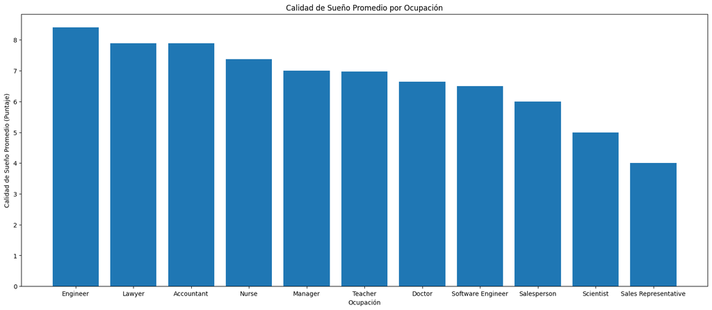

```python
df.columns = [str(col).strip() for col in df.columns]
count= df.groupby('Occupation')['Quality of Sleep'].mean().sort_values(ascending=False)
plt.figure(figsize=(20, 8))
plt.bar(count.index, count.values)
plt.title("Calidad de Sueño Promedio por Ocupación")
plt.xlabel("Ocupación")
plt.ylabel("Calidad de Sueño Promedio (Puntaje)")
plt.show()
```

5 ANALISIS DE DATOS

1. Contar los desordenes de sueño entre los hombres

```python
hombres_desorder = df[(df['Gender'] == 'Male') & (df['Sleep Disorder'] != 'None')]
```

```python
conteo = len(hombres_desorder)
```

```python
total_muestra = len(df)
```

```python
porcentaje = (conteo / total_muestra) * 100
```

```python
print(f"El porcentaje de hombres con desorden de sueño (respecto a la muestra completa) es: {porcentaje:.2f}%")
```

[output not shown]

2. Promedio de Duración del Sueño TOTAL

```python
promedio_duracion = df['Sleep Duration'].mean()
```

```python
print(f"El promedio de la duración del sueño en la muestra es de: {promedio_duracion:.2f} horas")
```

```
El promedio de la duración del sueño en la muestra es de: 7.13 horas
```

3. Promedio de Duración del Sueño (25 a 35 Años)

```python
rango_edad = df[(df['Age'] >= 25) & (df['Age'] <= 35)]
```

```python
promedio_rango = rango_edad['Sleep Duration'].mean()
```

```python
print(f"El promedio de duración del sueño para el rango de 25 y 35 años es de: {promedio_rango:.2f} horas")
```

```
El promedio de duración del sueño para el rango de 25 y 35 años es de: 6.85 horas
```

4. Ocupaciones Ordenadas por Presión Sanguínea Promedio

```python
df['Systolic Pressure'] = df['Blood Pressure'].apply(lambda x: int(x.split('/')[0]))
```

```python
promedio_presion = df.groupby('Occupation')['Systolic Pressure'].mean().sort_values(ascending=False)
```

```python
print(" Presión Sanguinea Promedio por Ocupación (Descendente)")
print(promedio_presion.to_string(header=True))
```

```
 Presión Sanguinea Promedio por Ocupación (Descendente)
Occupation
Sales Representative    140.000000
Nurse                   138.520548
Teacher                 131.225000
Salesperson             130.000000
Lawyer                  129.957447
Scientist               129.500000
Software Engineer       126.500000
Engineer                125.904762
Manager                 125.000000
Doctor                  123.000000
Accountant              117.729730
```

5. Correlación entre Pasos Diarios y Calidad de Sueño

```python
correlacion = df['Daily Steps'].corr(df['Quality of Sleep'])
```

```python
print(f"El Coeficiente de Correlación entre Pasos Diarios y Calidad de Sueño es: {correlacion:.4f}")
```

```
El Coeficiente de Correlación entre Pasos Diarios y Calidad de Sueño es: 0.0168
```

Dado que el valor es casi cero, indica que existe una correlación lineal muy debil (casi nula) entre el numero de pasos diarios y la calidad del sueño en esta muestra. Es decir, el numero de pasos que da una persona no es un predictor fuerte de su puntuación de calidad de sueño. La funcion .corr ayuda a sacar correlaciones, ayuda a hacer estos analisis estadisticos. Tipos de correlaciones que mide: Pearson (por defecto): mide la relación lineal. Kendall: mide relaciones ordinales. Spearman: mide relaciones monótonas.